# Spatial Relations Between DF voters and Non-Western Immigrant Populations

Ditte Hyldgaard Danielsen

2026-06-03

# Introduction

This project investigates the spatial relationship between support for the Danish People’s Party (DF) and the proportion of non-western immigrants across Danish municipalities.

The project combines choropleth mapping, correlation analysis, bivariate visualization, and local spatial autocorrelation (LISA) to explore how political and demographic patterns are geographically distributed.

## Setup

```r
#load libraries
library(sf)
library(tmap)
library(tidyverse)
library(leaflet)
library(spdep)
library(htmlwidgets)

tmap_mode("plot")
```

# Data Acquisition and Processing

The project combines three main datasets:

- Danish municipal population data
- Data on non-western immigrant populations
- Municipal election results for the Danish People’s Party

# Spatial Distribution of DF Support and Immigrant Populations

To explore regional variation, a choropleth map were created for both DF vote share and the proportion of non-western immigrants across Danish municipalities.

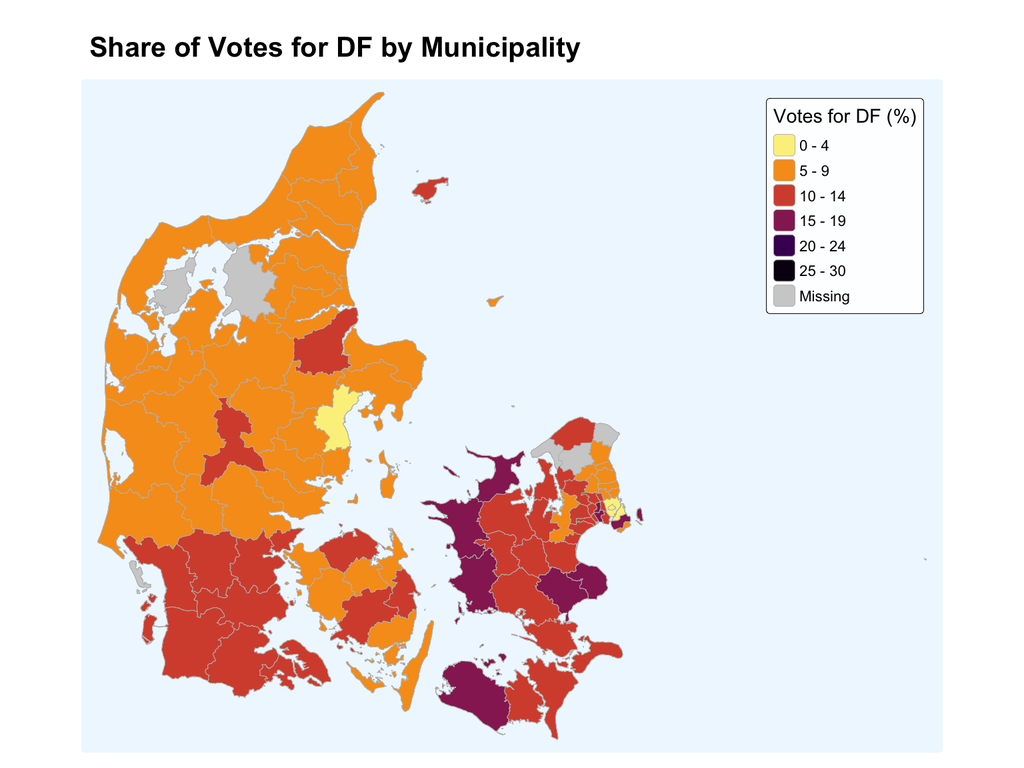

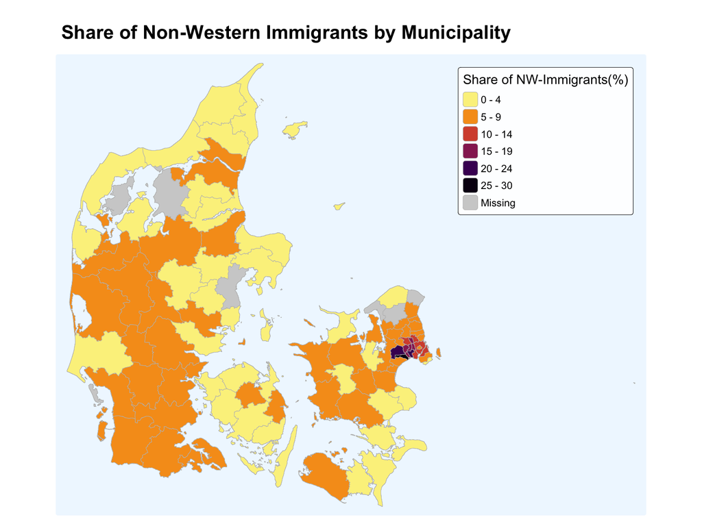

# Statistical Relationship Between Variables

To investigate whether municipalities with larger shares of non-western immigrants also display different levels of support for DF, a scatterplot and Pearson correlation analysis were conducted.

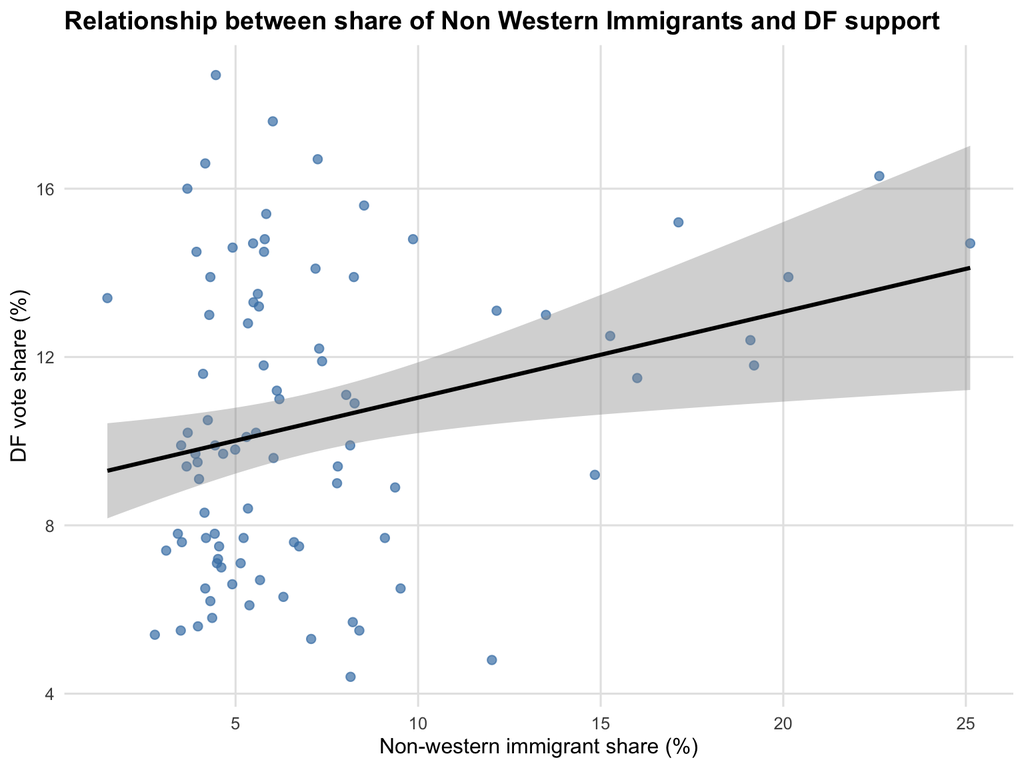

```r
# Caltulating Pearsons correlation
cor.test(data_clean$DF_share, data_clean$imm_share,
         use = "complete.obs")
```

```
##
##  Pearson's product-moment correlation
##
## data:  data_clean$DF_share and data_clean$imm_share
## t = 2.5952, df = 88, p-value = 0.01108
## alternative hypothesis: true correlation is not equal to 0
## 95 percent confidence interval:
##  0.06302183 0.44893516
## sample estimates:
##       cor
## 0.2666331
```

# Bivariate Spatial Visualization

To explore the spatial co-occurrence of DF support and immigrant share, an interactive bivariate choropleth map was created using `leaflet`.

The map classifies municipalities according to both variables, allowing exploration of areas with: - high DF support and low immigrant share, - low DF support and high immigrant share, - and mixed spatial patterns.

[interactive chart not shown]

# Local Spatial Autocorrelation (LISA)

To identify local spatial clustering of DF support, a Local Moran’s I analysis was conducted.

Local Indicators of Spatial Association (LISA) identify municipalities that are surrounded by neighboring municipalities with similarly high or low values.

| Cluster | Meaning |
| --- | --- |
| High–High | high DF surrounded by high DF |
| Low–Low | low DF surrounded by low DF |
| High–Low | outlier |
| Not significant | no strong spatial clustering |

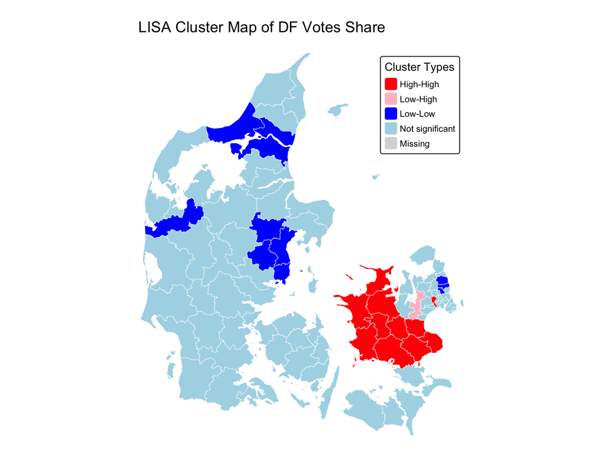

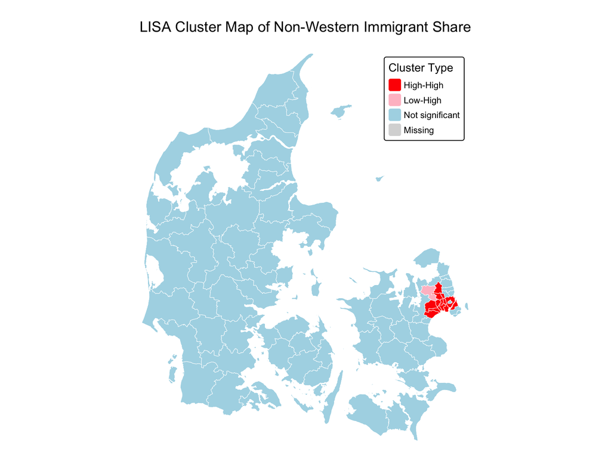